# Segmentation Methods II: Lavielle

#'

#' #'

#' #'

# Segmentation Methods II: Lavielle

#'

EFB 796: Techniques in Movement Ecology

#'

Elie Gurarie

#'

October 16, 2025

#' #'

#'

# Overview

#'

Lavielle segmentation is a statistical method for detecting multiple #' change-points in time series data, particularly useful for identifying #' distinct behavioral phases or movement patterns in animal trajectory #' data.

#'

The technique, developed by Lavielle (1999, 2005), uses a #' **penalized contrast approach** to partition a sequence of #' observations into homogeneous segments. The optimal number of segments, #' *k*, in the timeseries is then determined by minimizing the #' “penalized contrast function” (Lavielle 2005). Break points are #' (typically) determined using the mean, variance, or mean AND variance #' along the timeseries of the variable of interest (e.g., speed). An #' important underlying assumption is that in each phase, the model for the #' data is:

#'

$$X = {\cal N}(\mu_i,
#' \sigma_i)$$

#'

Barraquand and Benhamou (2008) adapted this approach specifically for #' animal movement analysis. It is useful for determining *behavioral #' changes*, and from those **homogeneous movement bouts** #' (what we term “phases”).

#'

The segmentation is ueually used to analyze *step lengths* or #' *movement rates* or even (quite effectively) the output of #' *first passage time* analyses. But here, we will (first) use it #' on absolute spatial location, for which it is an underutilized and #' useful tool.

#'

#'

#'

# Elk analysis

#'

First, let’s load in our processed data from lab 1.

#'

We will use one individual from our data as an example, “YL96”. This #' individual has some “patches” of residency-like behavior along its #' track.

#'

```r
myelk <- subset(elk_gps, id == "YL96") |>
#'   dplyr::mutate(id = as.character(id))
#'
#' str(myelk)
```

#'

```
## 'data.frame':    4129 obs. of  4 variables:
#' ##  $ datetime: POSIXct, format: "2004-03-29 17:00:00" "2004-03-29 19:02:00" ...
#' ##  $ lon     : num  -116 -116 -116 -116 -116 ...
#' ##  $ lat     : num  51.7 51.8 51.7 51.7 51.7 ...
#' ##  $ id      : chr  "YL96" "YL96" "YL96" "YL96" ...
```

#'

We can use Base R to visualize the track of this individual in space #' and time, using the methods we learned in lab 1:

#'

```r
par(mar = c(0,4,0,0), oma = c(4,0,5,2), xpd=NA)
#' layout(rbind(c(1,2), c(1,3)))
#' plot(myelk$lon, myelk$lat, asp = 1, type="o", ylab="Latitude", xlab="Longitude")
#' plot(myelk$datetime, myelk$lon, type="o", xaxt="n", ylab="Longitude", xlab="")
#' plot(myelk$datetime, myelk$lat, type="o", ylab="Latitude", xlab="Datetime")
#' title(paste("ID", myelk$id[1]), outer = TRUE)
```

#'

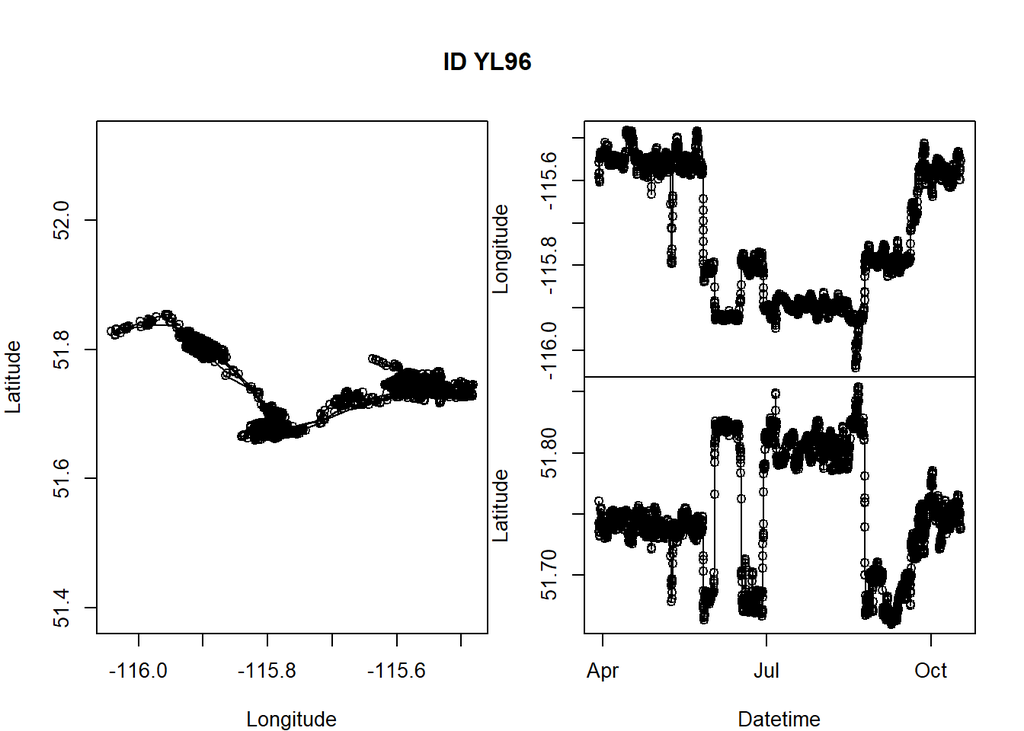

#'

#'

## Segmenting on positions

#'

Load the `adehabitatLT` package:

#'

```r
require(adehabitatLT)
```

#'

The Lavielle Method is fit using the `laveielle` function, #' where the user can specify the:

#'

1 - variable from the dataset to distinguish the segments by (here, #' we will use latitude) 2 - `Lmin` - the minimum number of #' relocations within a segment 3 - `Kmax` - the maximum number #' of segments to “try out” 4 - `type` - how to distinguish the #' segments (mean, variance, or both, “meanvar”)

#'

We can use the visualizations of our track to inform our decisions on #' these parameters.

#'

#'

```r
elk_lavielle_analysis <- lavielle(myelk$lat, Lmin = 20, Kmax = 20, type = "mean")
```

#'

After fitting, we can use the `chooseseg` function to #' identify the number of segments.

#'

```r
chooseseg(elk_lavielle_analysis)
```

#'

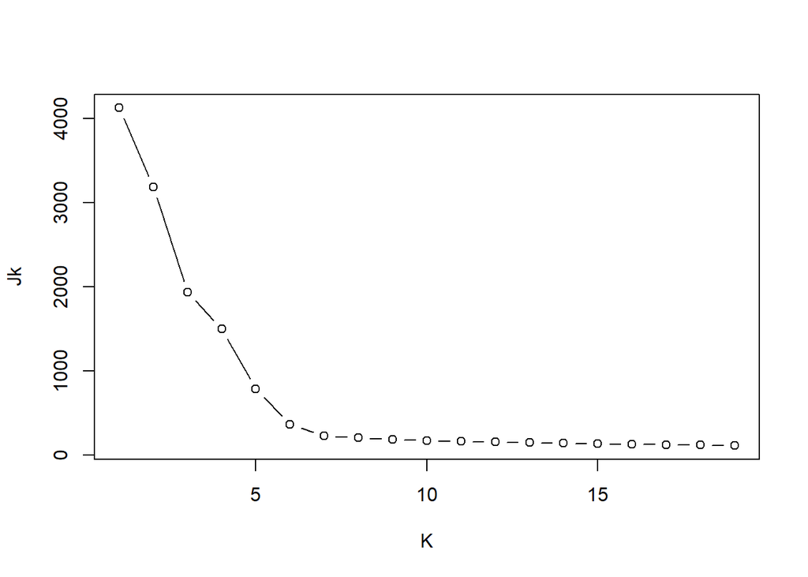

#'

```
##     K             D        Jk
#' ## 1   1           Inf 4128.0000
#' ## 2   2 -1.473818e+00 3187.2585
#' ## 3   3  3.860391e+00 1934.8893
#' ## 4   4 -1.307006e+00 1498.7706
#' ## 5   5  1.391509e+00  786.2955
#' ## 6   6  1.318898e+00  368.0444
#' ## 7   7  5.588243e-01  228.6644
#' ## 8   8  7.598953e-03  207.4435
#' ## 9   9  3.078294e-02  187.8293
#' ## 10 10  5.810296e-03  174.7240
#' ## 11 11  2.186967e-02  162.8472
#' ## 12 12  1.169060e-03  155.5946
#' ## 13 13  8.566054e-05  148.5892
#' ## 14 14  4.623611e-03  141.6019
#' ## 15 15  4.649277e-03  135.5922
#' ## 16 16 -4.649277e-03  130.5656
#' ## 17 17  9.169430e-03  124.5559
#' ## 18 18 -9.169430e-03  120.4850
#' ## 19 19  1.006426e-02  114.4753
```

#'

The plot shows a quantity $J_k$ #' which quantifies the total “cost” of that segmentation. This curve #' starts high (k=1) (all data in one segment = high variance), drops #' steeply (the first few segments capture major patterns), and then #' Flattens out, since additional segments provide minimal improvement. We #' therefore focus on the “elbow point” as a kind of “sweet spot” where #' each new segment substantially reduces unexplained variance. Looking at #' this, we might like 6 or 7 segments as having captured the most #' variation.

#'

We can now create a nice plot of these segments, with the change in #' latitude over time and the red lines delineating the break points for #' each segment.

#'

```r
breakpoints_list <- findpath(elk_lavielle_analysis, K = 6)
```

#'

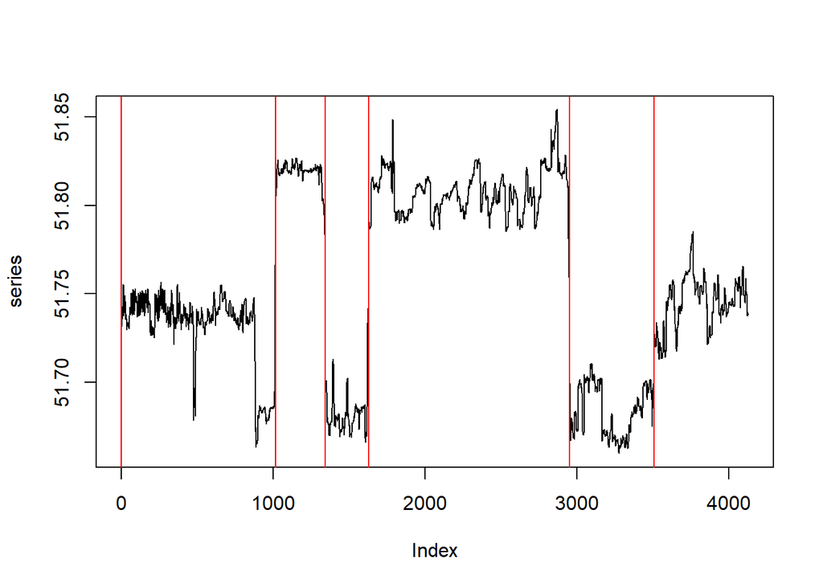

#'

easy - by the way - to see where the algorthim would but a seventh of #' eighth segment. You can decide how much you “really” need:

#'

```r
l7 <- findpath(elk_lavielle_analysis, K = 7)
```

#'

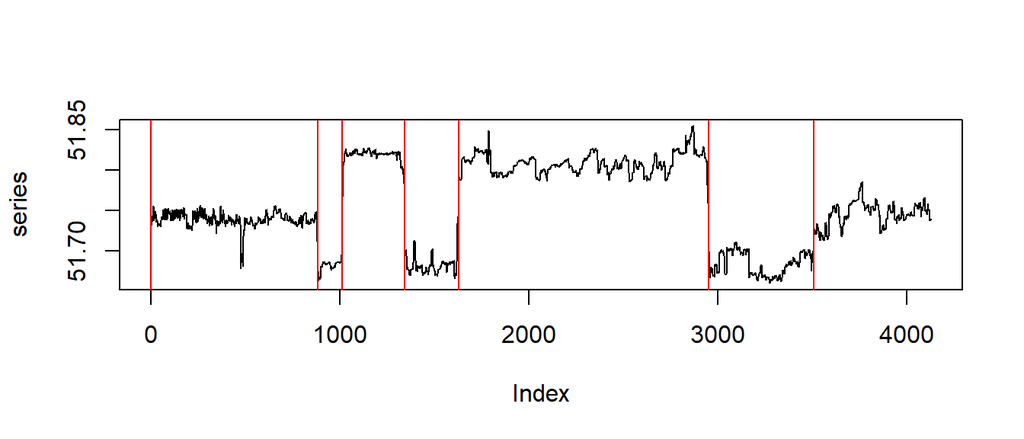

#'

```r
l8 <- findpath(elk_lavielle_analysis, K = 8)
```

#'

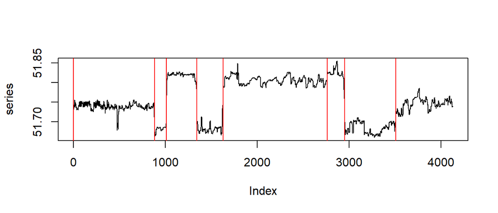

#'

Note, the output is a *list* of segments, which we can #' collapse into a single vector with `ldply` (recalling that #' `ld` means “from list to dataframe”).

#'

```r
require(plyr)
#' breakpoints <- ldply(breakpoints_list, rbind)
```

#'

Now, we can use those breakpoints to “augment” our raw data with the #' appropriate phase.

#'

```r
require(plyr)
#' cuts <- c(breakpoints[,1], nrow(myelk))
#' myelk <- myelk |>
#'   mutate(Row_ID = 1:nrow(myelk),
#'          phase = cut(Row_ID,
#'                      breaks = cuts,
#'                      include.lowest = TRUE, right = TRUE,
#'                      labels = 1:(length(cuts)-1)))
```

#'

We can visualize the final results in time::

#'

```r
require(ggplot2)
#' ggplot(data=myelk, aes(x=datetime, y=lat)) +
#'   geom_path(col = "grey") +
#'   geom_point(aes(color = phase)) +
#'   theme_classic()
```

#'

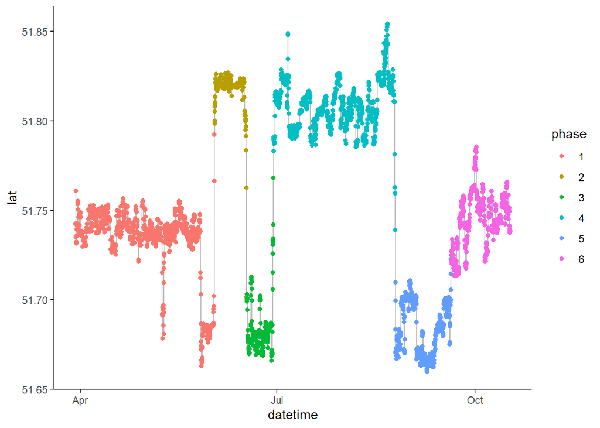

#'

In space:

#'

```r
ggplot(data=myelk, aes(x=lon, y=lat)) +
#'   geom_path(col = "grey") +
#'   geom_point(aes(color = phase)) +
#'   theme_classic()
```

#'

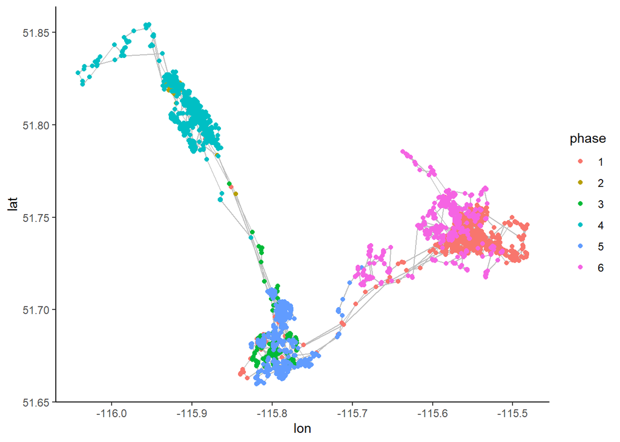

#'

Or in both (with my favorite scantrack):

#'

```r
layout(rbind(c(1,2), c(1,3)))
#' palette(gplots::rich.colors(6))
#' with(myelk, {
#'   plot(lon, lat, asp = 1, type="o", ylab="Latitude", xlab="Longitude", col = phase)
#'   plot(datetime, lon, type="o", xaxt="n", ylab="Longitude", xlab="", col = phase)
#'   plot(datetime, lat, type="o", ylab="Latitude", xlab="Datetime", col = phase)
#'   title(paste("ID", id[1]), outer = TRUE)
#' })
```

#'

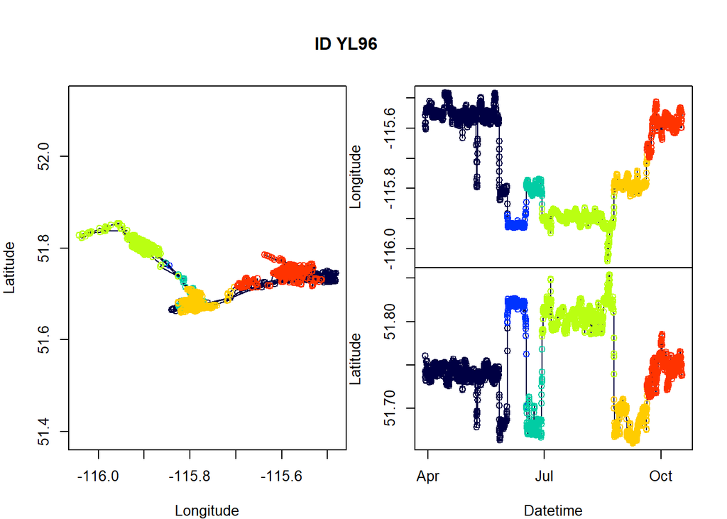

#'

This seems to work very well!

#'

> #'

> Exercise: Repeat this with 7 and 8 segments.

> #'

#'

#'

#'

## Segmenting on speeds

#'

A problem with this segmentation is that it does not separate #' transitional movements from the resident movements. It therefore might #' make more sense to do this on the *velocities* or #' *speeds*.

#'

First, obtain those velocities, using some of the augmentation code #' from before:

#'

```r
require(sf)
#' require(dplyr)
#'
#' elk_df <- elk_gps |>
#'   data.frame(elk_sf |> st_transform(32611) |> st_coordinates()) |>
#'   group_by(id) |>
#'   mutate(
#'       Z = X + 1i*Y,
#'         Step = c(NA, diff(Z)),
#'         StepLength = Mod(Step),
#'         dTime = c(NA, difftime(datetime[-1],
#'                             datetime[-length(datetime)],
#'                             units = "hours")),
#'         Speed = StepLength/dTime)
#'
#' myelk <- subset(elk_df, id == "YL96")
```

#'

Let’s look at the time series of the speed:

#'

```r
with(myelk,
#'   plot(datetime, Speed, type = "l"))
```

#'

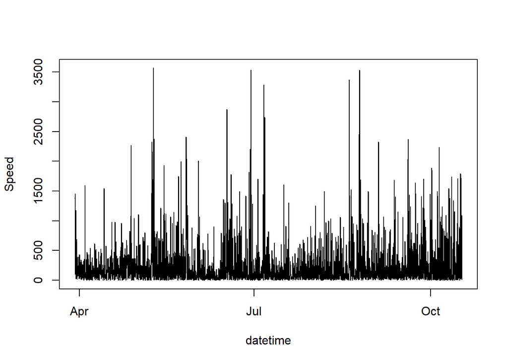

#'

There is a lot of data here! Also - it is not normal.

#'

```r
qqnorm(myelk$Speed)
```

#'

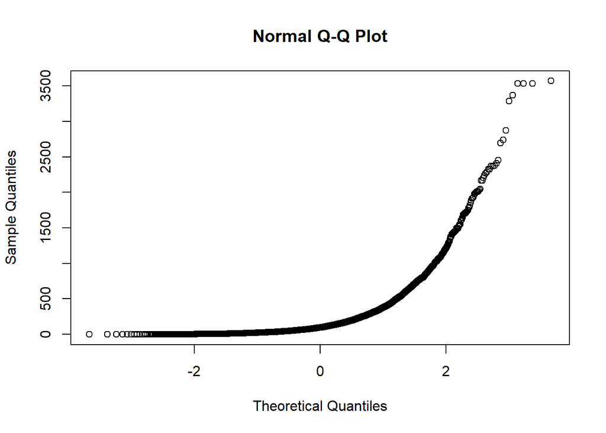

#'

The log trandform, on the other hand:

#'

```r
hist(log(myelk$Speed))
```

#'

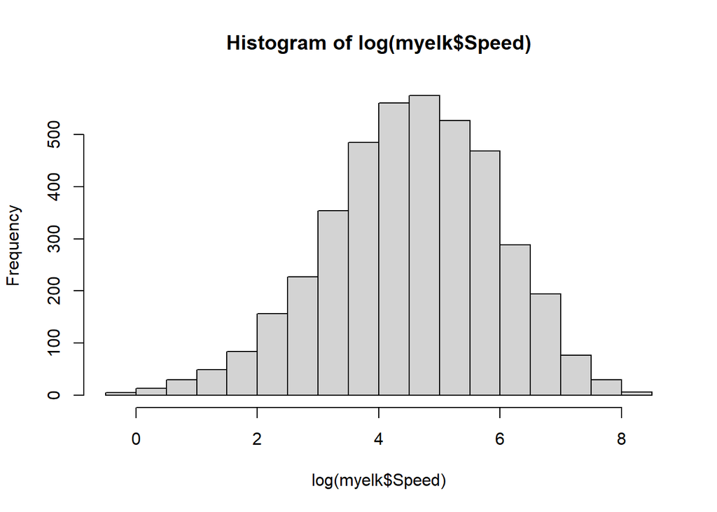

#'

```r
with(myelk, plot(datetime, log(Speed), type = "l"))
```

#'

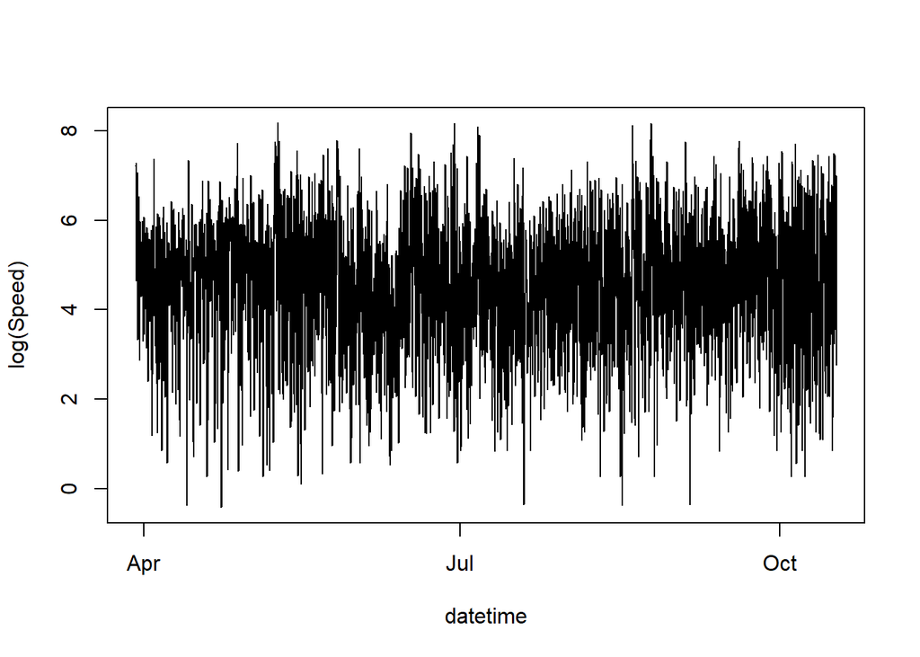

#'

Ok - are there some significant changes in here?

#'

> #'

> NOTE: For reasons that are unclear to me, the segmentation has a hard #' time with the complete dataset … so I subset an (interesting) portion of #' the data.

> #'

#'

```r
myelk_subset <- myelk[1000:1600,]
#' ggplot(myelk_subset, aes(X,Y)) + geom_path()
```

#'

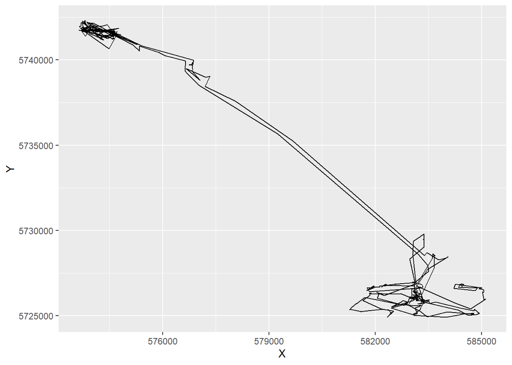

#'

```r
LogSpeed <- log(myelk_subset$Speed)[-1]
#' myelk_speed_lv <-  lavielle(LogSpeed, Lmin = 24, Kmax = 20, type = "mean")
```

#'

Choose the segments:

#'

```r
chooseseg(myelk_speed_lv)
```

#'

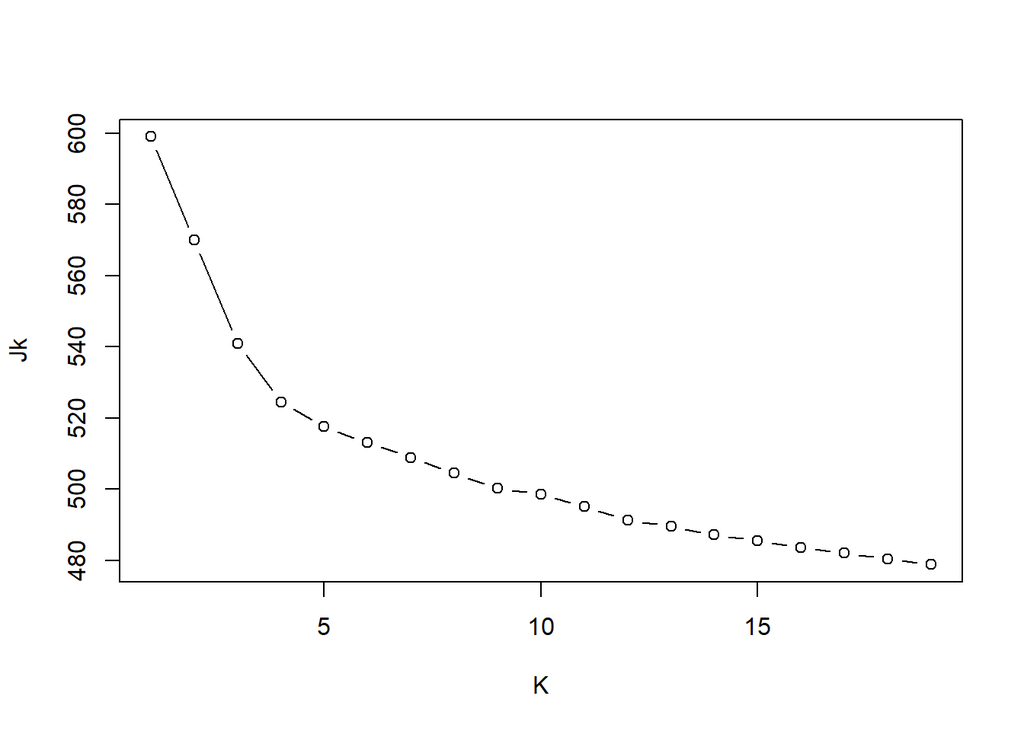

#'

```
##     K           D       Jk
#' ## 1   1         Inf 599.0000
#' ## 2   2  0.01141842 569.9330
#' ## 3   3  1.98088910 540.9388
#' ## 4   4  1.47080930 524.5613
#' ## 5   5  0.40417385 517.5518
#' ## 6   6  0.03930713 513.1167
#' ## 7   7 -0.03099897 508.9318
#' ## 8   8  0.02370299 504.5496
#' ## 9   9  0.39611962 500.3183
#' ## 10 10 -0.27836348 498.6100
#' ## 11 11 -0.03927880 495.1287
#' ## 12 12  0.30253461 491.3973
#' ## 13 13 -0.08932089 489.5927
#' ## 14 14  0.11688541 487.2193
#' ## 15 15 -0.03774008 485.5903
#' ## 16 16  0.03774008 483.7210
#' ## 17 17  0.01041840 482.0920
#' ## 18 18 -0.01041840 480.5294
#' ## 19 19  0.11185802 478.9005
```

#'

Find the breaks:

#'

```r
elk_segments <- findpath(myelk_speed_lv, 10)
```

#'

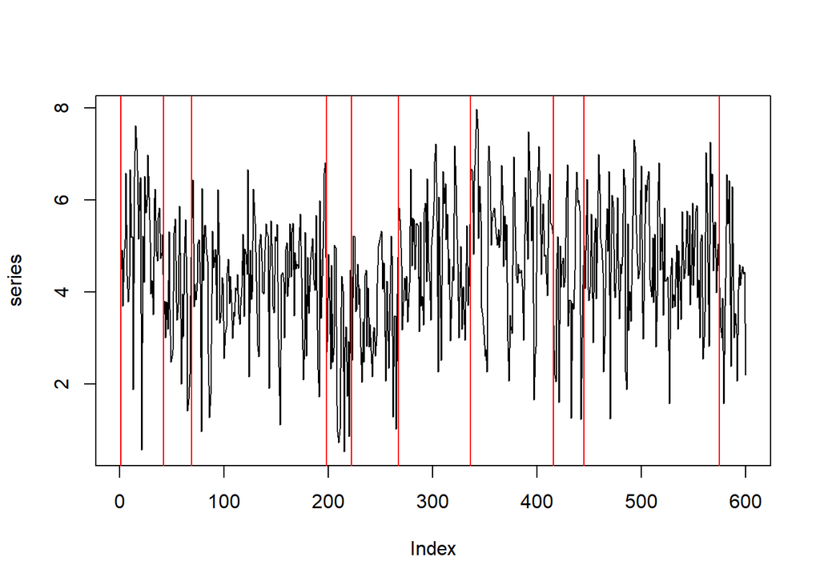

#'

```r
breakpoints <- ldply(elk_segments, rbind)
#' breakpoints
```

#'

```
##      1   2
#' ## 1    1  41
#' ## 2   42  68
#' ## 3   69 197
#' ## 4  198 221
#' ## 5  222 266
#' ## 6  267 335
#' ## 7  336 415
#' ## 8  416 444
#' ## 9  445 574
#' ## 10 575 600
```

#'

Add the breaks

#'

```r
require(plyr)
#' cuts <- c(breakpoints[,1]-.5, nrow(myelk))
#' myelk_subset <- myelk_subset |>
#'   mutate(Row_ID = 1:nrow(myelk_subset),
#'          speedphase = cut(Row_ID,
#'                      breaks = cuts,
#'                      labels = 1:nrow(breakpoints)))
```

#'

Visualize the time series

#'

```r
require(ggplot2)
#' ggplot(data=myelk_subset, aes(x=datetime, y=Speed)) +
#'   geom_path(col = "grey") +
#'   geom_point(aes(color = speedphase)) +
#'   theme_classic()
```

#'

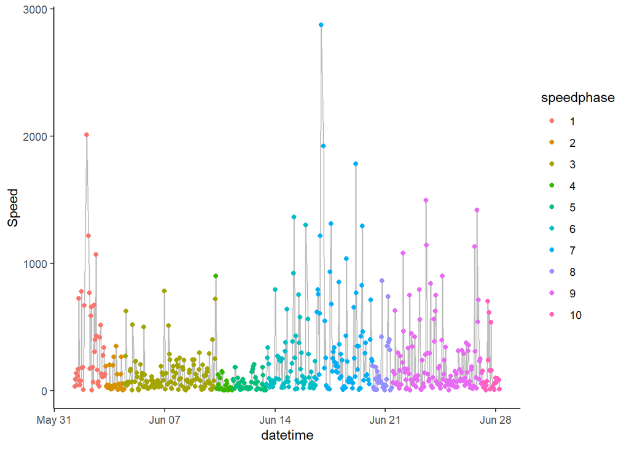

#'

Map with the phases:

#'

```r
require(ggplot2)
#' ggplot(data=myelk_subset, aes(x=lon, y=lat)) +
#'   geom_path(col = "grey") +
#'   geom_point(aes(color = speedphase)) +
#'   theme_classic()
```

#'

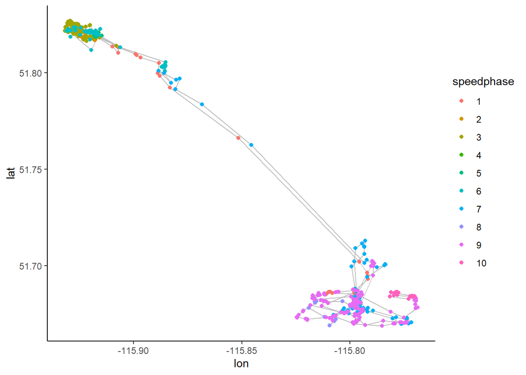

#'

How do the speeds compare across these phases?

#'

```r
myelk_subset |> ddply("speedphase", summarize,
#'   start = min(datetime),
#'   end = max(datetime),
#'   Speed.mean = mean(Speed),
#'   Speed.sd = sd(Speed))
```

#'

```
##    speedphase               start                 end Speed.mean  Speed.sd
#' ## 1           1 2004-06-01 07:00:00 2004-06-03 05:00:00  346.17152 403.69955
#' ## 2           2 2004-06-03 06:00:00 2004-06-04 10:00:00   82.73909  96.96007
#' ## 3           3 2004-06-04 11:00:00 2004-06-10 05:00:00  121.37098 136.01757
#' ## 4           4 2004-06-10 06:00:00 2004-06-11 07:00:00   74.45696 182.05090
#' ## 5           5 2004-06-11 08:00:00 2004-06-13 10:00:00   62.22718  59.33315
#' ## 6           6 2004-06-13 11:00:00 2004-06-16 14:00:00  217.41633 278.01513
#' ## 7           7 2004-06-16 15:02:00 2004-06-20 04:00:00  371.77028 490.38987
#' ## 8           8 2004-06-20 05:00:00 2004-06-21 10:00:00  167.54521 218.77738
#' ## 9           9 2004-06-21 11:00:00 2004-06-27 03:00:00  221.31655 285.88652
#' ## 10         10 2004-06-27 04:00:00 2004-06-28 06:00:00  129.61405 185.58351
```

#'

#'

#'

#'

# References

#'

#'

- Lavielle, M. 2005. Using penalized contrasts for the change-point #' problem. Signal Processing, 85, 1501–1510.

#'

- Lavielle, M. 1999. Detection of multiple changes in a sequence of #' dependent variables. Stochastic Processes and their Applications. 83, #' 79–102.

#'

- Barraquand, F. and Benhamou, S. 2008. Animal movements in #' heterogeneous landscapes: identifying profitable places and homogeneous #' movement bouts. Ecology, 89, 3336–3348.

#'

#'

#'

#' #'